# shapFlex::shapFlex() Speed

Nick Redell, nickredell@hotmail.com

2019-04-24

# Purpose

- The purpose of this vignette is to set expectations around the **runtime for `shapFlex::shapFlex()`** for commonly encountered machine learning problems. These simulations will get more involved after the package moves beyond “experimental” status.
- We won’t concern ourselves with estimating model parameter recovery in these simulations. While the ability of a sampling-based procedure like that used in `shapFlex::shapFlex()` to recover the ground truth is very important, this will be covered in another vignette.

# Simulation Design

- Calculate `shapFlex::shapFlex()` runtime for **1 instance**.
- Vary the monte carlo **sample size** and **number of model features**.
- Call `shapFlex::shapFlex()` **30 times** to estimate runtime variability.

# Simulation

## Load packages

```r
library(shapFlex)
library(glmnet)
library(ggplot2)
library(microbenchmark)
```

## Design

- The runtime of `shapFlex::shapFlex()` is dominated by the sampling procedure; namely, the function arguments “sample_size” and “target_features”. That said, we’ll predict on a small dataset of 100 rows with the LASSO algorithm to further minimize the impact of the user-supplied `predict()` function on runtime estimates.
- Simulation design:
  - Fixed:
    - Algorithm: LASSO
    - Number of rows to `predict()`: 100
  - Investigated:
    - Number of model features
    - Monte carlo sample size

```r
n_instances <- 100  # Fixed number of dataset rows for predict().

model_features <- c(10, 20, 100, 200)  # predictors.
sample_size <- c(30, 60, 90, 120)  # shapFlex(sample_size = ...).

# Design matrix for simulation
sim_design <- expand.grid(model_features, sample_size)
names(sim_design) <- c("model_features", "sample_size")
sim_design$condition <- 1:nrow(sim_design)

n_sim_conditions <- nrow(sim_design)  # Number of simulation conditions.

DT::datatable(sim_design)
```

|  | model_features | sample_size | condition |
| --- | --- | --- | --- |
| 1 | 10 | 30 | 1 |
| 2 | 20 | 30 | 2 |
| 3 | 100 | 30 | 3 |
| 4 | 200 | 30 | 4 |
| 5 | 10 | 60 | 5 |
| 6 | 20 | 60 | 6 |
| 7 | 100 | 60 | 7 |
| 8 | 200 | 60 | 8 |
| 9 | 10 | 90 | 9 |
| 10 | 20 | 90 | 10 |

[output cut: 6 more lines]

## Synthetic Data

- Because our primary concern is function speed, we’ll generate our model explanations with `shapFlex::shapFlex()` using completely random data with no relationship between the outcome and the features or correlation within the features themselves.
- 1 dataset of synthetic data for each condition in our simulation design.

```r
data_sim <- vector("list", n_sim_conditions)
for (i in 1:nrow(sim_design)) {

  y <- matrix(rnorm(n_instances), nrow = n_instances)
  x <- matrix(rnorm(n_instances * sim_design$model_features[i]), nrow = n_instances)
  data_sim[[i]] <- data.frame(cbind(y, x))
}
```

## Modeling

- 1 trained LASSO model for each condition in our simulation design.

```r
model_sim <- vector("list", nrow(sim_design))

for (i in 1:nrow(sim_design)) {

  model_sim[[i]] <- glmnet::cv.glmnet(x = as.matrix(data_sim[[i]][, -1]),
                                      y = as.matrix(data_sim[[i]][, 1, drop = FALSE], ncol = 1))
}
```

## shapFlex::shapFlex() Setup

### User-defined prediction function

- 1 prediction function for each condition in our simulation design.

```r
predict_ensemble <- function(models, data, ...) {

  y_pred <- data.frame(predict(models[[1]], as.matrix(data)))

  data_pred <- data.frame("y_pred" = y_pred)

  return(data_pred)
}
```

### Function arguments

```r
data_list <- lapply(1:n_sim_conditions, function(i) {list(data_sim[[i]][, -1])})
explain_instance <- 1  # we'll explain the first instance in each dataset.
model_list <- lapply(1:n_sim_conditions, function(i) {list(model_sim[[i]])})
predict_functions <- lapply(1:n_sim_conditions, function(i) {list("predict_ensemble")})
sample_size <- lapply(1:n_sim_conditions, function(i) {sim_design$sample_size[[i]]})
n_cores <- 1
```

## Run shapFlex::shapFlex() - 1 Core

```r
n_sim_rep_per_condition <- 30  # to estimate runtime variability

sim_results <- vector("list", nrow(sim_design))
set.seed(224)
for (i in seq_along(sim_results)) {

  sim_results[[i]] <- microbenchmark::microbenchmark(

    shapFlex::shapFlex(data = data_list[[i]],
                       explain_instance = explain_instance,
                       models = model_list[[i]],
                       predict_functions = predict_functions[[i]],
                       sample_size = sample_size[[i]],
                       n_cores = n_cores),
    times = n_sim_rep_per_condition
  )
  print(paste0(i, " ", Sys.time()))
}
data_sim <- lapply(sim_results, function(x) {data.frame("seconds" = x$time / 1e9)})
save(data_sim, file = "data_sim.Rda")
```

## Simulation Results

- Looking at both plots, it’s clear that the number of model features has a much greater influence on runtime than the sample size of the stochastic sampling procedure.
- The runtime increases approximately **linearly in sample size** and **exponentially in the number of model features**.
- As this package develops, we’ll look closer at the relationship between sample size, number of model features, runtime, and parameter recovery to provide recommended `shapFlex::shapFlex()` settings for different machine learning problems.

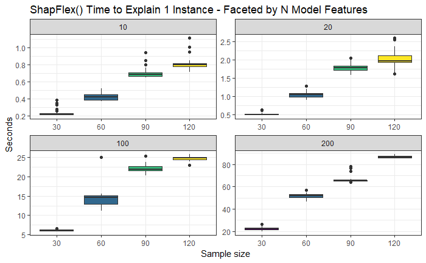

```r
data_plot <- dplyr::bind_rows(data_sim, .id = "condition")
data_plot$condition <- as.integer(data_plot$condition)

data_plot <- dplyr::left_join(data_plot, sim_design, by = "condition")
data_plot$sample_size <- ordered(data_plot$sample_size)
data_plot$model_features <- ordered(data_plot$model_features)

p <- ggplot(data_plot, aes(sample_size, seconds, fill = sample_size))
p <- p + geom_boxplot()
p <- p + scale_fill_viridis_d()
p <- p + facet_wrap(~ model_features, scales = "free")
p <- p + theme_bw() + theme(legend.position = "none") +
  xlab("Sample size") + ylab("Seconds") +
  ggtitle("ShapFlex() Time to Explain 1 Instance - Faceted by N Model Features")
p
```

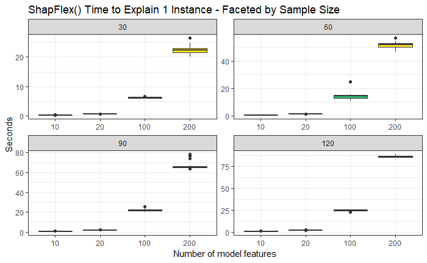

```r
p <- ggplot(data_plot, aes(model_features, seconds, fill = model_features))
p <- p + geom_boxplot()
p <- p + scale_fill_viridis_d()
p <- p + facet_wrap(~ sample_size, scales = "free")
p <- p + theme_bw() + theme(legend.position = "none") +
  xlab("Number of model features") + ylab("Seconds") +
  ggtitle("ShapFlex() Time to Explain 1 Instance - Faceted by Sample Size")
p
```